# Assignment 1

GDAA 2010 | Dr. Steven Edwards | George Lee Tannous

## Assignment #1 Applied Machine Learning

### Introduction

In today's data-driven world, machine learning has become an essential tool for making sense of large amounts of data. The ability to build accurate predictive models from data has numerous applications across industries, from finance and healthcare to marketing and cybersecurity. For my first assignment in this course, I will be exploring the "Heart Attack Analysis & Prediction" dataset created by Rashik Rahman and sourced from Kaggle. Using various machine learning techniques, I will make class label predictions based on the data in the dataset. The main objective of this dataset is to evaluate the impact of various contributors on one's health and the likelihood of heart attack, which will be the target variable for this analysis. To evaluate the effectiveness of the models, I will compare and evaluate the results against industry-standard metrics, including accuracy score, area under the curve values and confusion matrices.

https://www.kaggle.com/datasets/rashikrahmanpritom/heart-attack-analysis-prediction-dataset

### Alogorithms

The machine learning algorithms that will be executed on the Heart Attack Analysis & Prediction dataset are Support Vector Machines, Decision Trees, and Random Forests.

Support Vector Machines

```
: SVM is a supervised machine learning algorithm used for classification and regression tasks. It works by finding the best hyperplane that separates the data into different classes. It tries to maximize the margin between the hyperplane and the closest data points of each class. SVM can handle both linear and non-linear data, and is particularly effective for high-dimensional data.
```

Decision Trees

```
: Decision Trees are a simple yet powerful classification algorithm that work by recursively splitting the data based on the features that provide the most information gain. Each split divides the data into two or more subgroups, with the goal of eventually producing a set of homogeneous groups. Decision Trees are easy to interpret and visualize, but they can suffer from overfitting and lack of generalization.
```

Random Forests

```
: Random Forests is an ensemble learning method that combines multiple decision trees to improve the overall accuracy and robustness of the model. The individual trees in a Random Forest are constructed using random subsets of the data and features, and their results are aggregated to produce the final prediction. This method reduces the risk of overfitting and improves the ability of the model to generalize to new data.
```

## Summary of Variables in Heart Attack Prediction Dataset

Age : Age of the patient

Sex : Sex of the patient

exang: exercise induced angina (1 = yes; 0 = no)

slp: slope

caa: number of major vessels

cp : Chest Pain type chest pain type

```
Value 1: typical angina
Value 2: atypical angina
Value 3: non-anginal pain
Value 4: asymptomatic
```

trtbps : resting blood pressure (in mm Hg)

chol : cholestoral in mg/dl fetched via BMI sensor

thall: thalium stress test ~ (0.3)

fbs : (fasting blood sugar > 120 mg/dl)

```
1 = true; 0 = false
```

rest_ecg : resting electrocardiographic results

```
Value 0: normal
Value 1: having ST-T wave abnormality (T wave inversions and/or ST elevation or depression of > 0.05 mV)
Value 2: showing probable or definite left ventricular hypertrophy by Estes' criteria
```

thalach : maximum heart rate achieved

target:

```
0= less chance of heart attack
1= more chance of heart attack
```

sourced from Kaggle(https://www.kaggle.com/datasets/rashikrahmanpritom/heart-attack-analysis-prediction-dataset)

## Step 1. Load the Required Packages

```python
import pandas as pd
from matplotlib import pyplot as plt
import seaborn as sns
```

```python
# Importing the Heart Attack dataset as a pandas dataframe.
df = pd.read_csv('heart.csv')
# Printing the head to see if it imported properly.
df.head()
```

|  | age | sex | cp | trtbps | chol | fbs | restecg | thalachh | exng | oldpeak | slp | caa | thall | output |
| --- | --- | --- | --- | --- | --- | --- | --- | --- | --- | --- | --- | --- | --- | --- |
| 0 | 63 | 1 | 3 | 145 | 233 | 1 | 0 | 150 | 0 | 2.3 | 0 | 0 | 1 | 1 |
| 1 | 37 | 1 | 2 | 130 | 250 | 0 | 1 | 187 | 0 | 3.5 | 0 | 0 | 2 | 1 |
| 2 | 41 | 0 | 1 | 130 | 204 | 0 | 0 | 172 | 0 | 1.4 | 2 | 0 | 2 | 1 |
| 3 | 56 | 1 | 1 | 120 | 236 | 0 | 1 | 178 | 0 | 0.8 | 2 | 0 | 2 | 1 |
| 4 | 57 | 0 | 0 | 120 | 354 | 0 | 1 | 163 | 1 | 0.6 | 2 | 0 | 2 | 1 |

```python
# By printing out the missing values in the dataset, we can get an idea of how much data is missing and which columns have missing values,
# which can help us decide how to handle them in the data cleaning process.
missing_values = pd.DataFrame({'Missing Values': df.isnull().sum()})
missing_values
```

|  | Missing Values |
| --- | --- |
| age | 0 |
| sex | 0 |
| cp | 0 |
| trtbps | 0 |
| chol | 0 |
| fbs | 0 |
| restecg | 0 |
| thalachh | 0 |
| exng | 0 |
| oldpeak | 0 |
| slp | 0 |
| caa | 0 |
| thall | 0 |
| output | 0 |

```python
# Define categorical and continuous variables
cat_cols = ['sex', 'cp', 'fbs', 'restecg', 'exng', 'slp', 'caa', 'thall']
con_cols = ['age', 'trtbps', 'chol', 'thalachh', 'oldpeak']

# Print the list of categorical and continuous variables
print('Categorical variables:', cat_cols)
print('Continuous variables:' ,con_cols)

# Create dataframes for categorical and continuous variables
cat_df = df[cat_cols]
con_df = df[con_cols]

# We are defining categorical and continuous variables in order to separate out the variables by their type.
# This is because different types of variables require different types of analysis and visualization methods.
```

```
Categorical variables: ['sex', 'cp', 'fbs', 'restecg', 'exng', 'slp', 'caa', 'thall']
Continuous variables: ['age', 'trtbps', 'chol', 'thalachh', 'oldpeak']
```

```python
# We are printing the summary statistics of the continuous variables to gain a better understanding of their characteristics and distribution
con_df.describe()
```

|  | age | trtbps | chol | thalachh | oldpeak |
| --- | --- | --- | --- | --- | --- |
| count | 303.000000 | 303.000000 | 303.000000 | 303.000000 | 303.000000 |
| mean | 54.366337 | 131.623762 | 246.264026 | 149.646865 | 1.039604 |
| std | 9.082101 | 17.538143 | 51.830751 | 22.905161 | 1.161075 |
| min | 29.000000 | 94.000000 | 126.000000 | 71.000000 | 0.000000 |
| 25% | 47.500000 | 120.000000 | 211.000000 | 133.500000 | 0.000000 |
| 50% | 55.000000 | 130.000000 | 240.000000 | 153.000000 | 0.800000 |
| 75% | 61.000000 | 140.000000 | 274.500000 | 166.000000 | 1.600000 |
| max | 77.000000 | 200.000000 | 564.000000 | 202.000000 | 6.200000 |

```python
# The variables have different scales, with age ranging from 29 to 77, trtbps ranging from 94 to 200, chol ranging from 126 to 564, thalachh ranging from 71 to 202, and oldpeak ranging from 0 to 6.2.
# The standard deviation for all variables is relatively low, indicating that the data points are not too far from the mean.
```

## Step 2. Exploratory Data Analysis

After loading the necessary packages and importing the dataset, we have done some preliminary work to understand the dataset. Now, it's time to explore the dataset more deeply. This exploration will allow us to gain more insight into the data and identify any patterns or relationships between the variables. By exploring the data, we can uncover important features that may impact our machine learning models and help us make informed decisions about data preprocessing and feature engineering. Additionally, it can help us identify any potential data quality issues that may need to be addressed.

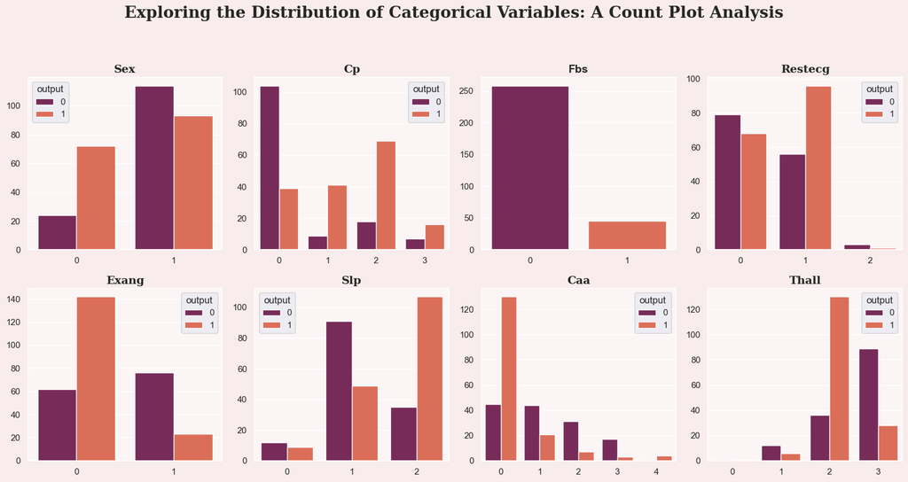

```python
# Set figure size and background color
fig, axs = plt.subplots(nrows=2, ncols=4, figsize=(16, 8))
fig.patch.set_facecolor('#f9ecec')

# Set background color for each axis object
for ax in axs.flatten():
    ax.set_facecolor('#fcf5f5')

# Plot the count plots
sns.countplot(ax=axs[0, 0], x='sex', data=df, palette='rocket', hue='output')
sns.countplot(ax=axs[0, 1], x='cp', data=df, palette='rocket', hue='output')
sns.countplot(ax=axs[0, 2], x='fbs', data=df, palette='rocket')
sns.countplot(ax=axs[0, 3], x='restecg', data=df, palette='rocket', hue='output')
sns.countplot(ax=axs[1, 0], x='exng', data=df, palette='rocket', hue='output')
sns.countplot(ax=axs[1, 1], x='slp', data=df, palette='rocket', hue= 'output')
sns.countplot(ax=axs[1, 2], x='caa', data=df, palette='rocket', hue='output')
sns.countplot(ax=axs[1, 3], x='thall', data=df, palette='rocket', hue='output')

# Set titles and axis labels
axs[0, 0].set_title('Sex', fontsize=14, fontweight='bold', fontname='serif')
axs[0, 1].set_title('Cp', fontsize=14, fontweight='bold', fontname='serif')
axs[0, 2].set_title('Fbs', fontsize=14, fontweight='bold')
axs[0, 3].set_title('Restecg', fontsize=14, fontweight='bold', fontname='serif')
axs[1, 0].set_title('Exang', fontsize=14, fontweight='bold', fontname='serif')
axs[1, 1].set_title('Slp', fontsize=14, fontweight='bold', fontname='serif')
axs[1, 2].set_title('Caa', fontsize=14, fontweight='bold', fontname='serif')
axs[1, 3].set_title('Thall', fontsize=14, fontweight='bold', fontname='serif')

axs[0, 0].set_xlabel('')
axs[0, 1].set_xlabel('')
axs[0, 2].set_xlabel('')
axs[0, 3].set_xlabel('')
axs[1, 0].set_xlabel('')
axs[1, 1].set_xlabel('')
axs[1, 2].set_xlabel('')
axs[1, 3].set_xlabel('')

axs[0, 0].set_ylabel('')
axs[0, 1].set_ylabel('')
axs[0, 2].set_ylabel('')
axs[0, 3].set_ylabel('')
axs[1, 0].set_ylabel('')
axs[1, 1].set_ylabel('')
axs[1, 2].set_ylabel('')
axs[1, 3].set_ylabel('')

# Add the overall title to the set of subplots
fig.suptitle('Exploring the Distribution of Categorical Variables: A Count Plot Analysis', fontsize=20, fontweight='bold', fontname='serif', y=1.05)

plt.tight_layout()
plt.show()
```

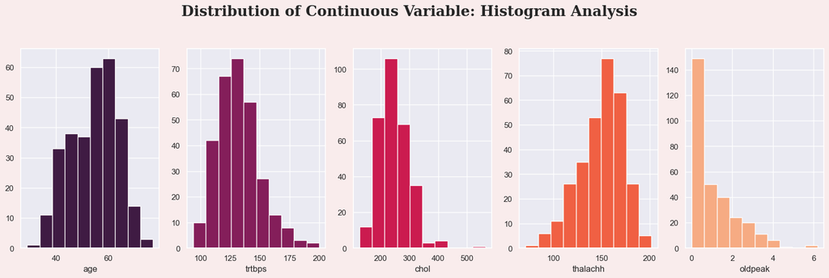

```python
# Set the color palette
colors = sns.color_palette('rocket', n_colors=len(con_cols))

fig, axs = plt.subplots(nrows=1, ncols=len(con_cols), figsize=(20,5))
fig.patch.set_facecolor('#f9ecec')


# Plot a histogram for each variable
for i, col in enumerate(con_cols):
    axs[i].hist(df[col], color=colors[i])
    axs[i].set_xlabel(col)

# Add the overall title to the set of subplots
fig.suptitle('Distribution of Continuous Variable: Histogram Analysis', fontsize=20, fontweight='bold', fontname='serif', y=1.05)

# Show the plot
plt.show()
```

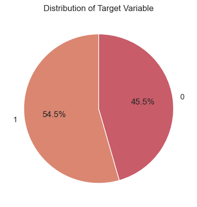

```python
# Count the number of instances for each target value
output_counts = df['output'].value_counts()

# Define the color palette
colors = sns.color_palette('flare', 4, desat=0.8)

# Create the pie chart
plt.pie(output_counts, labels=output_counts.index, colors=colors, autopct='%1.1f%%', startangle=90)

# Add title
plt.title('Distribution of Target Variable')

# Display the chart
plt.show()
```

In many cases, having a slightly imbalanced dataset is not necessarily a problem and does not require further balancing. A distribution of 54.5% and 45.5% is relatively close to an even distribution and could be considered well-balanced. Furthermore, balancing the dataset could potentially lead to a loss of important information and result in reduced model performance. Therefore, in this scenario, it may be appropriate to proceed with the current distribution without further balancing the dataset.

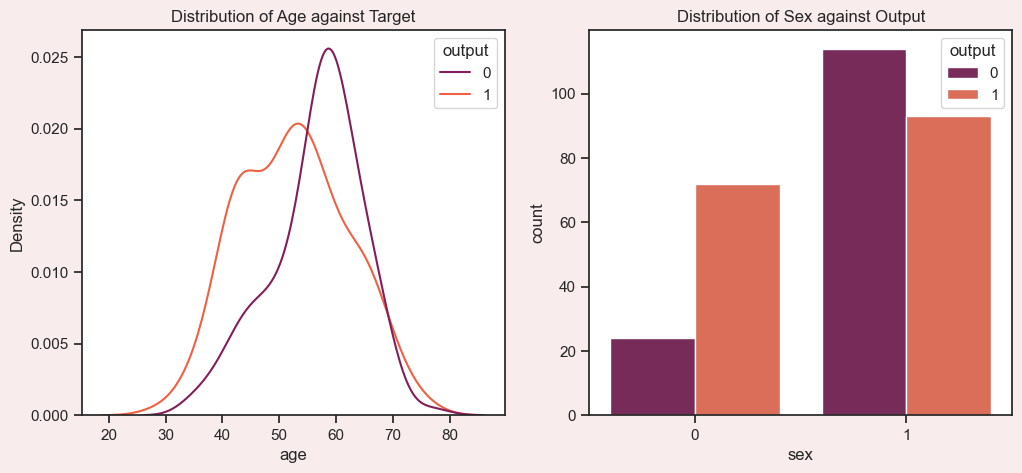

```python
# # Create a figure with 1 row and 2 columns of subplots, with a figure size of (12, 5)
fig, axs = plt.subplots(nrows=1, ncols=2, figsize=(12, 5))
fig.patch.set_facecolor('#f9ecec')

# Plot distribution of age against target
sns.kdeplot(data=df, x='age', hue='output', ax=axs[0], palette='rocket')

# Plot distribution of sex against output
sns.countplot(data=df, x='sex', hue='output', ax=axs[1], palette='rocket')

# Add titles to the plots
axs[0].set_title('Distribution of Age against Target')
axs[1].set_title('Distribution of Sex against Output')

# Display the plot
plt.show()
```

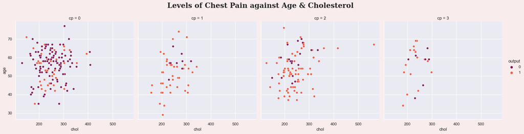

```python
# Create a scatter plot with multiple subplots
g = sns.relplot(x='chol', y='age', hue='output', data=df, col='cp', palette='rocket')

# Add a title and adjust subplot spacing
g.fig.suptitle('Levels of Chest Pain against Age & Cholesterol', fontsize=20, fontweight='bold', fontname='serif', y=1.05)
plt.subplots_adjust(top=0.90)

# Set background color of plot
g.fig.patch.set_facecolor('#f9ecec')

# Show the plot
plt.show()
```

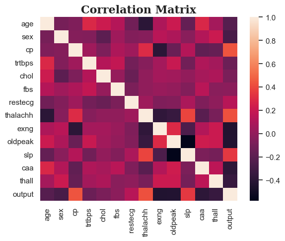

```python
sns.heatmap(df.corr())
plt.title('Correlation Matrix', fontsize=16, fontweight='bold', fontname='serif')
plt.show()
```

The scatterplot heatmap matrix provides a visual representation of the pairwise correlation between multiple variables in a dataset. Upon examining the heatmap, we can see that there are indications of a possible correlation between the target variable "output" and the 'cp', 'thalachh', and 'slp' features. This suggests that changes in these features may have an impact on the likelihood of experiencing a heart attack.

## 3. Data Cleaning / Preperation

```python
# Check for duplicates in the dataframe
duplicates = df.duplicated()

# Count the number of duplicates
num_duplicates = duplicates.sum()

# Print the number of duplicates
print("Number of duplicates:", num_duplicates)
print(df.loc[duplicates])
```

```
Number of duplicates: 1
     age  sex  cp  trtbps  chol  fbs  restecg  thalachh  exng  oldpeak  slp  \
164   38    1   2     138   175    0        1       173     0      0.0    2

     caa  thall  output
164    4      2       1
```

The dataset contains only one duplicate row, which is indexed at 164 and includes information related to a person. Since this duplicate row does not pose any problems to the data, it has been decided to retain it in the dataset.

## 4. Define Target and Predictor Variables

```python
Y = df['output'].values

X = df.drop(labels = ['output'], axis = 1)
print(X.head)
```

```
<bound method NDFrame.head of      age  sex  cp  trtbps  chol  fbs  restecg  thalachh  exng  oldpeak  slp  \
0     63    1   3     145   233    1        0       150     0      2.3    0
1     37    1   2     130   250    0        1       187     0      3.5    0
2     41    0   1     130   204    0        0       172     0      1.4    2
3     56    1   1     120   236    0        1       178     0      0.8    2
4     57    0   0     120   354    0        1       163     1      0.6    2
..   ...  ...  ..     ...   ...  ...      ...       ...   ...      ...  ...
298   57    0   0     140   241    0        1       123     1      0.2    1
299   45    1   3     110   264    0        1       132     0      1.2    1
300   68    1   0     144   193    1        1       141     0      3.4    1
301   57    1   0     130   131    0        1       115     1      1.2    1
302   57    0   1     130   236    0        0       174     0      0.0    1

     caa  thall
0      0      1
1      0      2
2      0      2
3      0      2
4      0      2
..   ...    ...
298    0      3
299    0      3
300    2      3
301    1      3
302    1      2

[303 rows x 13 columns]>
```

## 5. Partition Data into Training and Testing Sets

Partitioning the data into training and testing sets using the train_test_split function from the sklearn library. We have specified the test size as 0.2, which means that 20% of the data will be used for testing and the remaining 80% will be used for training the model. This helps to evaluate the performance of the model on unseen data and prevents overfitting to the training data.

```python
# Train Test Split
from sklearn.model_selection import train_test_split
```

```python
X_train, X_test, y_train, y_test = train_test_split(X, Y, test_size=0.2, random_state=42)
print(X_test)
```

```
     age  sex  cp  trtbps  chol  fbs  restecg  thalachh  exng  oldpeak  slp  \
179   57    1   0     150   276    0        0       112     1      0.6    1
228   59    1   3     170   288    0        0       159     0      0.2    1
111   57    1   2     150   126    1        1       173     0      0.2    2
246   56    0   0     134   409    0        0       150     1      1.9    1
60    71    0   2     110   265    1        0       130     0      0.0    2
..   ...  ...  ..     ...   ...  ...      ...       ...   ...      ...  ...
249   69    1   2     140   254    0        0       146     0      2.0    1
104   50    1   2     129   196    0        1       163     0      0.0    2
300   68    1   0     144   193    1        1       141     0      3.4    1
193   60    1   0     145   282    0        0       142     1      2.8    1
184   50    1   0     150   243    0        0       128     0      2.6    1

     caa  thall
179    1      1
228    0      3
111    1      3
246    2      3
60     1      2
..   ...    ...
249    3      3
104    0      2
300    2      3
193    2      3
184    0      3

[61 rows x 13 columns]
```

## 6. Modelling

In this code, we are importing and setting up several models for our data. We have imported the RobustScaler from the sklearn library, which is a method for scaling data in order to remove the effect of outliers. We are also importing three different models: SVM (Support Vector Machine), Random Forest Classifier, and Decision Tree Classifier. These are all commonly used models for classification tasks.

We have also imported some metrics for evaluating the performance of our models. The metrics we have chosen to use are accuracy score, confusion matrix, and ROC AUC score. The accuracy score measures the percentage of correctly classified instances, the confusion matrix shows the number of true and false positive and negative classifications, and the ROC AUC score is a measure of the overall performance of a classification model.

```python
# Scaling
from sklearn.preprocessing import RobustScaler

# Models
from sklearn import svm
from sklearn.ensemble import RandomForestClassifier
from sklearn.tree import DecisionTreeClassifier

# Metrics
from sklearn.metrics import accuracy_score, confusion_matrix, roc_auc_score
```

```python
# Creating the SVM Model
clf = svm.SVC()

# Training the model on the training data
clf.fit(X_train,y_train)

# Predicting on the test data
prediction_test = clf.predict(X_test)
print("The test accuracy score of SVM is ", accuracy_score(y_test, prediction_test))
```

```
The test accuracy score of SVM is  0.7049180327868853
```

After obtaining a less-than-satisfactory test accuracy score using the Support Vector Machine (SVM) model, I decided to scale the data to see if it would improve the model's performance. To do this, I imported the RobustScaler class from the scikit-learn library and applied it to the training and testing sets.

Scaling the data is important because some machine learning algorithms, such as SVM, are sensitive to unscaled data. This can result in inaccurate predictions and poor model performance. By applying RobustScaler, I was able to normalize the features in the dataset and bring them all to a similar scale, ensuring that the SVM model was working with appropriately scaled data.

After scaling the data, I created a new SVM model and trained it on the scaled training data. I then used this model to make predictions on the scaled test data and evaluated its accuracy using the accuracy_score function. Additionally, I calculated the ROC AUC score and created a confusion matrix to further evaluate the model's performance.

```
The test accuracy score of SVM is  0.8524590163934426
The ROC AUC score of SVM is  0.8512931034482758
```

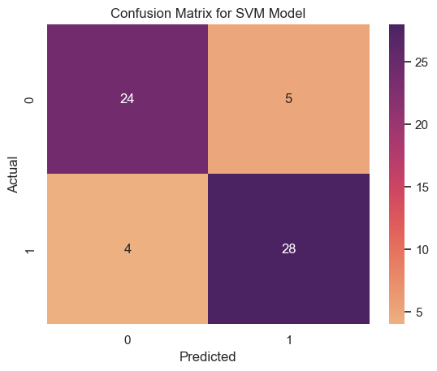

```python
# Scaling the data
scaler = RobustScaler()
X_train_scaled = scaler.fit_transform(X_train)
X_test_scaled = scaler.transform(X_test)

# Creating the SVM model
clf = svm.SVC()

# Training the model on the scaled training data
clf.fit(X_train_scaled, y_train)

# Predicting on the scaled test data
prediction_test = clf.predict(X_test_scaled)

# Evaluating the model's accuracy on the scaled test data
print("The test accuracy score of SVM is ", accuracy_score(y_test, prediction_test))

# Get the ROC AUC score
roc_auc = roc_auc_score(y_test, prediction_test)
print("The ROC AUC score of SVM is ", roc_auc)

# Creating a confusion matrix
cm = confusion_matrix(y_test, prediction_test)

# PLottingc confusion matrix
sns.heatmap(cm, annot=True, fmt='g', cmap='flare')

plt.xlabel('Predicted')
plt.ylabel('Actual')
plt.title('Confusion Matrix for SVM Model')

plt.show()
```

After running the SVM model on the initial dataset, the accuracy score was only 70%. Upon further inspection, it was noted that SVM is sensitive to unscaled data. The scaled data was then used to train the SVM model, and the accuracy score was found to be improved to 85%. This is a significant improvement from the initial score. To validate the model, a confusion matrix was created which showed the actual results in the test data. The confusion matrix had a total of 61 samples, with 24 samples correctly predicted as negative and 28 samples correctly predicted as positive. However, the model misclassified 5 negative samples as positive and 4 positive samples as negative. Overall, scaling the data helped improve the accuracy of the SVM model in predicting heart disease.

```
The test accuracy score of Random Forest is  0.8852459016393442
The ROC AUC score of Random Forest is  0.8841594827586207
```

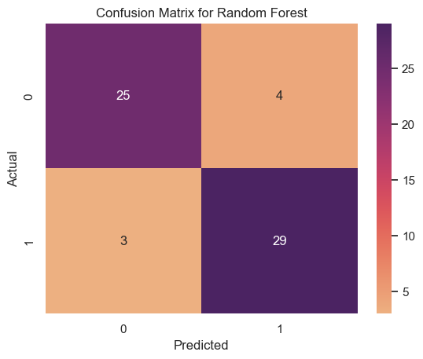

```python
# Creating the Random Forests Model
rf = RandomForestClassifier()

# Training the model on the training data
rf.fit(X_train,y_train)

# Predicting on the test data
prediction_test = rf.predict(X_test)
print("The test accuracy score of Random Forest is ", accuracy_score(y_test, prediction_test))

# Get the ROC AUC score
roc_auc = roc_auc_score(y_test, prediction_test)
print("The ROC AUC score of Random Forest is ", roc_auc)

# Creating a confusion matrix
cm = confusion_matrix(y_test, prediction_test)

# PLottingc confusion matrix
sns.heatmap(cm, annot=True, fmt='g', cmap='flare')

plt.xlabel('Predicted')
plt.ylabel('Actual')
plt.title('Confusion Matrix for Random Forest')

plt.show()
```

```
The test accuracy score of  Decision Tree is  0.8360655737704918
The ROC AUC score of  Decision Tree is  0.8389008620689655
```

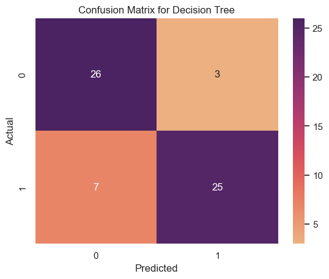

```python
# Creating the Decision Tree Model
dt = DecisionTreeClassifier()

# Training the model on the training data
dt.fit(X_train,y_train)

# Predicting on the test data
prediction_test = dt.predict(X_test)
print("The test accuracy score of  Decision Tree is ", accuracy_score(y_test, prediction_test))

# Get the ROC AUC score
roc_auc = roc_auc_score(y_test, prediction_test)
print("The ROC AUC score of  Decision Tree is ", roc_auc)

# Creating a confusion matrix
cm = confusion_matrix(y_test, prediction_test)

# PLottingc confusion matrix
sns.heatmap(cm, annot=True, fmt='g', cmap='flare')

plt.xlabel('Predicted')
plt.ylabel('Actual')
plt.title('Confusion Matrix for Decision Tree')

plt.show()
```

In order to implement the Decision Tree model, the DecisionTreeClassifier model from the scikit-learn library was instantiated and trained on the training data. The model's output was then predicted on the test data and the accuracy score was calculated using the accuracy_score() function, resulting in a score of 83%. The ROC AUC score was also computed using the roc_auc_score() function, yielding a score of 83%. To gain further insights into the model's performance, a confusion matrix was generated using the confusion_matrix() function and visualized using a seaborn heatmap. The confusion matrix revealed that the model accurately predicted 25 positive and 26 negative samples, but misclassified 7 positive samples as negative and 3 negative samples as positive out of a total of 61 samples. While the Decision Tree model performed reasonably well on the dataset, it did not perform as well as the SVM model scaled or the Random Forest model.

## 7. Discussion

In conclusion, Random Forest appears to be the most effective model for predicting heart attacks in the provided dataset due to its ability to manage non-linear correlations between the target variable and the features. As an ensemble model, Random Forest builds several decision trees by utilizing random subsets of the data and features and merges their outcomes to deliver the final prediction. This characteristic decreases the probability of overfitting, a common issue with Decision Trees. Additionally, the Random Forest algorithm overcomes many issues associated with individual decision trees by introducing randomness and aggregation into the equation. Each tree is built independently using a random portion of the data and a random subset of the features at each node, with predictions made for each tree. For classification problems, the most frequent prediction is used, while for regression problems, the average prediction from all the individual trees is used as the output value. As more trees are added to the model, a broader range of data is considered, and more features are used, resulting in a robust, aggregated model.